# Lasso Regression for Oncology Utilization Management

A report on Lasso Regression for data science projects - Fall 2025

Vijayavel Mohanam, Jennifer Nesbit and Sassou Khabou (Advisor: Dr. Cohen)

2025-12-03

## Background

- The rising complexity of cancer care and treatment decision-making requires robust tools to support utilization management.
- Clinical decisions (radiation, chemotherapy) involve multiple tumor characteristics and patient specific factors.
- Simple regression may risk overfitting or multicollinearity with multiple variables.
- Regularization methods such as Lasso regression or Ridge regression offer a way to build predictive models that are both accurate and interpretable.
- Using data from SEER can provide generalizable insights into treatment patterns.

## Problem Statement

- Given tumor characteristics and patient demographics for breast cancer, can we accurately predict whether a patient receives radiation therapy or chemotherapy?
- Which factors (tumor, demographic, staging, receptor status, etc.) most strongly influence treatment decisions? Can we build a model that balances predictive performance and clinical interpretability?

## Objectives

- Use SEER data (breast cancer cases) to model treatment received.
- Apply penalized regression to select key predictors and avoid overfitting.
- Evaluate regularization approaches (Lasso) in terms of feature selection, interpretability and predictive performance.
- Provide a model structure that could support utilization management workflows.

## Dataset Overview

- Source: SEER Registry, Breast Cancer Cases (2018–2022)
- SEER dataset provides high quality, standardized data:
- Allows for large-scale analyses of cancer patterns, treatments and outcomes
- Includes diverse populations in the United States
- Dataset includes tumor characteristics, staging, receptor status, demographics.
- Filtered for valid cases with complete data for modeling

## Variables & Data Preparation

- Ctegorized into three groups: treatment variables, tumor characteristics, and patient demographics. Treatment outcomes (radiation, chemotherapy) were derived from SEER treatment summary fields and were recoded into binary 0/1 outcomes indicating whether treatment was administered.
- Tumor characteristics included tumor size (continuous), summary stage, nodal involvement (N0–N3), metastatic spread (bone/brain/liver/lung/lymph nodes), grade, laterality, and ER/PR/HER2 status. Each variable was cleaned, recoded, and mapped into clinically meaningful categories.
- Demographic variables included age groups, sex, detailed race/ethnicity classifications, marital status (partnered vs. unpartnered), reporting source, and year of diagnosis. All demographic fields were standardized to ensure consistency.
- Extensive recoding and filtering were applied: exclusion of cases with missing or unknown key staging/biomarker values, retention of only first primary malignancies, and removal of non-applicable or inconsistent categories.
- Categorical predictors were transformed into binary variables and all numeric variables were standardized prior to Lasso modeling to ensure consistent scaling and appropriate penalty application.

## Lasso Regression: Concept & Rationale

- Lasso = Linear/Logistic regression + **L1 penalty**.
- Causes some coefficients to shrink to **zero** allowing for:
  - Automated feature selection
  - Reduced complexity
- Useful in multivariable healthcare datasets
- Combines predictive accuracy with interpretability

## Modeling Approach

- Two separate Lasso regression models were developed to identify predictors of first-line radiation and chemotherapy use among breast cancer patients in the SEER dataset.
- Categorical variables were expanded into a full model matrix using model.matrix() to ensure compatibility with the Lasso penalty structure; the treatment variable (radiation or chemotherapy) was isolated as a numeric outcome vector.
- Predictor matrices were fit across a grid of λ penalty values using glmnet with alpha = 1, allowing automatic variable selection through coefficient shrinkage.
- Ten-fold cross-validation (cv.glmnet) was used to determine the λ that minimized prediction error, ensuring an optimal balance of model complexity and stability.
- Final models emphasized interpretability and generalizability, supporting real-world utilization management needs where consistent, evidence-based treatment prediction is essential.

## Modeling Implementation

- **Tools:** R glmnet package
- **Process:** Clean & encode data – Standardize predictors – Cross-validation to select λ – Fit final Lasso model – Extract non-zero coefficients

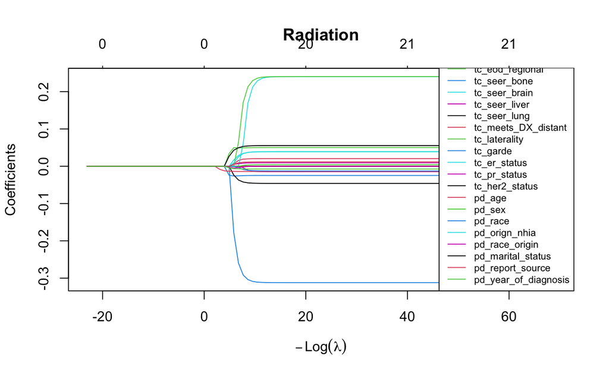

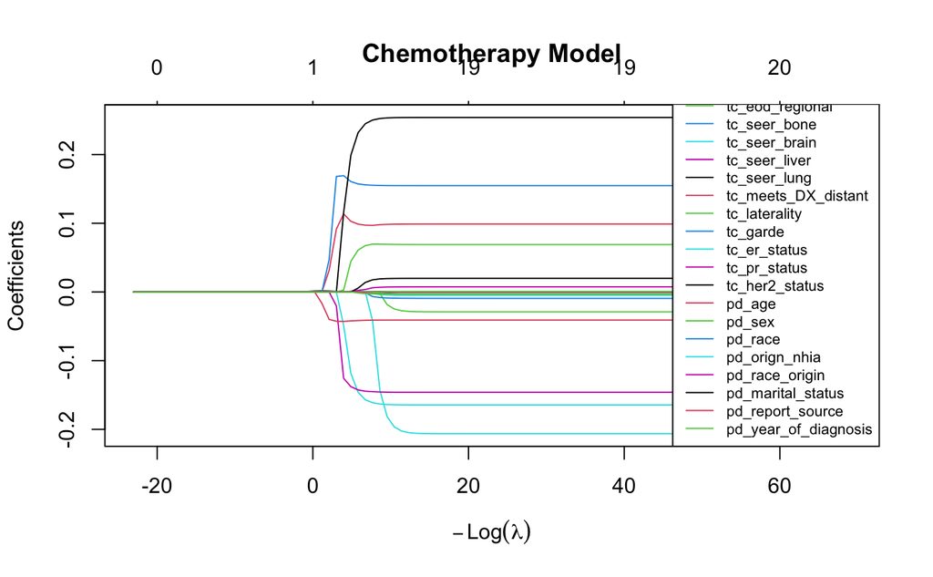

## Results - Radiation Model

Predictors that kept non-zero coefficients that were > 0.05

[output not shown]

## Results - Chemotherapy Model

Predictors that kept non-zero coefficients that were > 0.05

[output not shown]

## Clinical Implications

- Helps understand which patient/tumor features drive treatment decisions.
- Useful for utilization management and auditing consistency.
- Supports data-driven policy review and resource planning.
- Transparent model makes results accessible to clinicians and administrators.

## Limitations

- SEER data lacks specific clinical factors such as comorbidities, genomic panels and patient preference.
- Only first-course treatment was captured in this model.
- Missing data or coding inconsistencies may influence results.
- Lasso does not capture non-linear relationships or interactions.

## References

Adamo M., Dickie L., & Ruhl, J. (2018). SEER Program Coding and Staging Manual 2018. National Cancer Institute.  
Ali, Shahzad, H. 2023. “Application and Impact of Lasso Regression in Gastroenterology.” A Systematic Review. Indian J Gastroenterol 42, 780–790 (2023).  
Li, Bai, Y. 2023. “Prognostic Nomograms for Gastric Carcinoma After D2 + Total Gastrectomy to Assist Decision-Making for Postoperative Treatment: Based on Lasso Regression.” World Journal of Surgical Oncology, 21(1), Article 207.  
Muthukrishnan, R., and R. Rohini. 2016. “LASSO: A Feature Selection Technique in Predictive Modeling for Machine Learning.” IEEE International Conference on Advances in Computer Applications (ICACA), Coimbatore, India, 2016, Pp. 18-20.  
Tibshirani, Robert. 1996. “Regression Shrinkage and Selection Via the Lasso.” Journal of the Royal Statistical Society: Series B (Methodological), Volume 58, Issue 1, January 1996, Pages 267–288.  
Vidaurre, Concha Bielza, Diego, and Pedro Larrañaga. 2013. “A Survey of L1 Regression.” International Statistical Review 81 (3): 361–87.